# Mouse TxDb from different sources

```r
if (!requireNamespace("BiocManager", quietly = TRUE))
    install.packages("BiocManager")

### It may take long time
if(BiocManager::version()<"3.10")
  BiocManager::install(version = "3.10")
```

To get gene level analysis from Salmon output which is in trnscript level we need the information of transcript_id <–> gene_id mapping. There are different way to get this information. Here few of them will be evaluated. Following packages are required.

```r
if(!require("tximport"))
        BiocManager::install("tximport")
if(!require("GenomicFeatures"))
       BiocManager::install("GenomicFeatures")
if(!require("AnnotationDbi"))
        BiocManager::install("AnnotationDbi")
if(!require("tidyverse"))
        install.packages("tidyverse")
if(!require("gplots"))
  install.packages("gplots")
if(!require("RMariaDB"))
  install.packages("RMariaDB")

library(tidyverse)
library(AnnotationDbi)
library(tximport)
```

First , let us import a sample RNA-seq data aligned to Mouse transcript.

```r
quant <- read_delim("salmon_quant/non_rRna_trimmed_Derm5Ctrl_run032119.good.fq_quant/quant.sf",
    "\t", escape_double = FALSE, trim_ws = TRUE)
head(quant)
```

| Name | Length | EffectiveLength | TPM | NumReads |
| --- | --- | --- | --- | --- |
| ENSMUST00000177564 | 16 | 3.119 | 0 | 0 |
| ENSMUST00000196221 | 9 | 2.818 | 0 | 0 |
| ENSMUST00000179664 | 11 | 2.954 | 0 | 0 |
| ENSMUST00000178537 | 12 | 3.002 | 0 | 0 |
| ENSMUST00000178862 | 14 | 3.071 | 0 | 0 |
| ENSMUST00000179520 | 11 | 2.954 | 0 | 0 |

# TX<==>Gene

The reads are aligned to 117081 transcripts (TX) and the TX identifiers are from Ensembl. We need transcript <==> gene mapping info to get the gene level expression values.

There are different sources to get these mappings.

## From package

Search for right package for your organism based on your requirement from [bioconductor](http://bioconductor.org/packages/release/BiocViews.html#___Organism)

```r
BiocManager::available("Mmusculus")
```

```
 [1] "BSgenome.Mmusculus.UCSC.mm10"
 [2] "BSgenome.Mmusculus.UCSC.mm10.masked"
 [3] "BSgenome.Mmusculus.UCSC.mm8"
 [4] "BSgenome.Mmusculus.UCSC.mm8.masked"
 [5] "BSgenome.Mmusculus.UCSC.mm9"
 [6] "BSgenome.Mmusculus.UCSC.mm9.masked"
 [7] "EnsDb.Mmusculus.v75"
 [8] "EnsDb.Mmusculus.v79"
 [9] "PWMEnrich.Mmusculus.background"
[10] "TxDb.Mmusculus.UCSC.mm10.ensGene"
[11] "TxDb.Mmusculus.UCSC.mm10.knownGene"
[12] "TxDb.Mmusculus.UCSC.mm9.knownGene"
```

“EnsDb.Mmusculus.v79” looks like provide mapping from Ensembl database.

```r
if(!require("EnsDb.Mmusculus.v79"))
  BiocManager::install("EnsDb.Mmusculus.v79")

library("EnsDb.Mmusculus.v79")
txdb_pkg <- EnsDb.Mmusculus.v79
# columns(txdb_pkg)
k <- keys(txdb_pkg, keytype="TXID")
tx2gene_pkg <- AnnotationDbi::select(txdb_pkg, k, "GENEID", "TXID")

# head(tx2gene_pkg)
dim(tx2gene_pkg)
```

```
[1] 104129      2
```

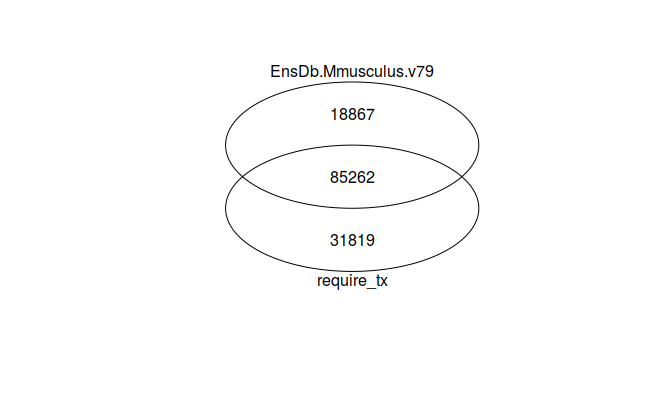

```r
gplots::venn(list(require_tx=quant$Name, EnsDb.Mmusculus.v79= tx2gene_pkg$TXID))
```

Information about 30k TX ids are **missing**

## GTF file

We can download the GTF file from Ensemble and use it.

```r
download.file(url = "ftp://ftp.ensembl.org/pub/release-99/gtf/mus_musculus/Mus_musculus.GRCm38.99.gtf.gz",
              destfile = "Mus_musculus.GRCm38.99.gtf.gz")
TxGTF <- GenomicFeatures::makeTxDbFromGFF(file = "Mus_musculus.GRCm38.99.gtf.gz")
 k <- keys(TxGTF, keytype = "TXNAME")
 tx2gene_gtf <- AnnotationDbi::select(TxGTF, k, "GENEID", "TXNAME")
 # head(tx2gene)
 dim(tx2gene_gtf)
```

```
[1] 142647      2
```

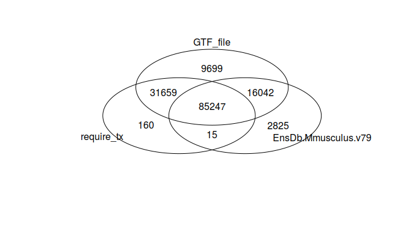

```r
gplots::venn(list(require_tx=quant$Name, EnsDb.Mmusculus.v79= tx2gene_pkg$TXID, GTF_file=tx2gene_gtf$TXNAME))
```

The GTF provides more but not all the Tx ids

## Pkg:GenomicFeatures

It is also possible to download this information from Ensembl directly

```r
mmusculusEnsembl_biomart <- GenomicFeatures::makeTxDbFromEnsembl(organism = "Mus musculus", release = 99)
saveRDS(mmusculusEnsembl_biomart, file = "mmusculusEnsembl_biomart.rds")
```

```r
mmusculusEnsembl_biomart <- GenomicFeatures::makeTxDbFromEnsembl(organism = "Mus musculus", release = 99)
k <- keys(mmusculusEnsembl_biomart, keytype = "TXNAME")
tx2gene_bm <- select(mmusculusEnsembl_biomart, k, "GENEID", "TXNAME")
# head(tx2gene_bm)
dim(tx2gene_bm)
```

```
[1] 144726      2
```

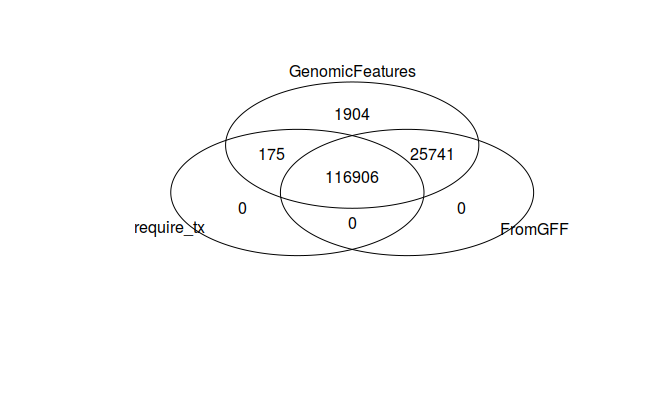

```r
gplots::venn(list(require_tx=quant$Name, FromGFF=tx2gene_gtf$TXNAME, GenomicFeatures = tx2gene_bm$TXNAME))
```

**GenomicFeatures** successfully downloaded all the required Tx ids.

## ensembldb

Using [ensembldb](https://bioconductor.org/packages/release/bioc/html/ensembldb.html) suggested by tximport following [this](http://bioconductor.org/packages/release/bioc/vignettes/ensembldb/inst/doc/ensembldb.html) tutorial. [Always check latest updated documentation]

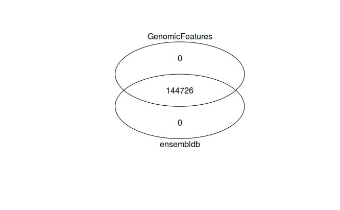

```r
if(!require("AnnotationHub"))
  install.packages("AnnotationHub")

library(AnnotationHub)

mouse_query <- AnnotationHub::query(AnnotationHub(), c("mus musculus","EnsDb",99))
mouse_Ensdb <- mouse_query[[1]]
# listColumns(mouse_Ensdb)

tx2gene_ensembldb <- transcripts(mouse_Ensdb,
          columns = c("tx_id", "gene_id"),
          return.type = "DataFrame")

gplots::venn(list(ensembldb=tx2gene_ensembldb$tx_id, GenomicFeatures = tx2gene_bm$TXNAME))
```

**ensembldb** provides identical Tx ids compare to GenomicFeatures

# Conclusion

- Always better to cross check different sources.
- GenomicFeatures == ensembldb
- ensembldb faster than other methods